# **PCFL 2022: Week 8 wrap-up**

Last week was ANOTHER week with no recap, but the travel’s over, so I should be back in the saddle the rest of the season.

## Last week’s games

| Winner | Winner’s score | Loser | Loser’s score |
| --- | --- | --- | --- |
| Georgia Peanuts | 130.66 | Jumpin’ Jaheims | 107.12 |
| Middle Earth Hangry Hobbits | 140.89 | Captain Clairvoyant | 91.78 |
| The Juniors | 118.98 | The G.O.A.T. | 112.80 |
| Athens Team Sasquatch | 153.85 | Southern Sharks | 150.26 |
| Pigskin on the Gridiron | 96.54 | KC Gophers | 70.94 |

My guys have been up and down this year, but this was a BIG week for the Georgia Peanuts, ending Evan’s time as the last undefeated team. We also had a shootout between the Sasquatch and the Sharks, who ended up 1 and 2 in scoring as Robbie came out on top. The Hobbits also dominated, and Erin/Trav eked out a win against Jacob.

## Best performances

### Best players overall

Here’s last week’s **10 best performing starters.**

| Player | Position | NFL Team | Points | PCFL Team |
| --- | --- | --- | --- | --- |
| Alvin Kamara | RB | NOS | 38.30 | Athens Team Sasquatch |
| A.J. Brown | WR | PHI | 36.60 | Athens Team Sasquatch |
| Christian McCaffrey | RB | SFO | 36.26 | The Juniors |
| Derrick Henry | RB | TEN | 35.30 | Southern Sharks |
| Tony Pollard | RB | DAL | 33.20 | Middle Earth Hangry Hobbits |
| D’Onta Foreman | RB/WR/TE | CAR | 31.80 | Pigskin on the Gridiron |
| Jalen Hurts | QB | PHI | 28.40 | Georgia Peanuts |
| DeAndre Hopkins | WR | ARI | 27.90 | Georgia Peanuts |
| Jaylen Waddle | WR | MIA | 26.60 | Middle Earth Hangry Hobbits |
| Tyreek Hill | WR | MIA | 25.50 | The Juniors |
| DJ Moore | WR | CAR | 25.50 | Southern Sharks |

Alvin Kamara had an Alvin Kamara week, and Christian McCaffrey didn’t take long to settle in with his new team.

### Best players per team

Here’s last week’s top players **on each team.**

| Player | Position | NFL Team | Points | PCFL Team |
| --- | --- | --- | --- | --- |
| Alvin Kamara | RB | NOS | 38.30 | Athens Team Sasquatch |
| Nick Chubb | RB | CLE | 24.90 | Captain Clairvoyant |
| Jalen Hurts | QB | PHI | 28.40 | Georgia Peanuts |
| Lamar Jackson | QB | BAL | 21.82 | Jumpin’ Jaheims |
| Kirk Cousins | BE | MIN | 23.48 | KC Gophers |
| Tony Pollard | RB | DAL | 33.20 | Middle Earth Hangry Hobbits |
| D’Onta Foreman | RB/WR/TE | CAR | 31.80 | Pigskin on the Gridiron |
| Derrick Henry | RB | TEN | 35.30 | Southern Sharks |
| Dak Prescott | QB | DAL | 25.40 | The G.O.A.T. |
| Christian McCaffrey | RB | SFO | 36.26 | The Juniors |

Pretty much everyone made the starting lineup here, except for Kirk Cousins on the Gophers.

### Best bench

Who won the **best scoring bench** award last week?

| Team | Bench points |
| --- | --- |
| KC Gophers | 97.08 |
| Georgia Peanuts | 66.58 |
| Captain Clairvoyant | 62.54 |
| The G.O.A.T. | 57.28 |
| Jumpin’ Jaheims | 54.95 |
| Southern Sharks | 51.96 |
| Middle Earth Hangry Hobbits | 46.93 |
| Pigskin on the Gridiron | 38.60 |
| Athens Team Sasquatch | 36.65 |
| The Juniors | 29.00 |

Go Gophers!

Here’s the season’s bench standings:

| Team | Bench points |
| --- | --- |
| KC Gophers | 526.05 |
| Middle Earth Hangry Hobbits | 513.23 |
| The G.O.A.T. | 509.10 |
| Jumpin’ Jaheims | 487.83 |
| Southern Sharks | 421.14 |
| Pigskin on the Gridiron | 401.19 |
| The Juniors | 375.09 |
| Georgia Peanuts | 365.60 |
| Captain Clairvoyant | 333.02 |
| Athens Team Sasquatch | 327.77 |

### Best optimized lineups

I compared the actual starting lineups for each team to the hypothetical *best* starting lineup the owner could have started. The table below shows the actual points the team scored, the top score they could have had, and an “optimization” percentage that compares to the two.

| PCFL Team | Actual points | Best lineup | Optimization rate |
| --- | --- | --- | --- |
| Southern Sharks | 150.26 | 152.16 | 99% |
| Middle Earth Hangry Hobbits | 140.89 | 145.43 | 97% |
| Athens Team Sasquatch | 153.85 | 165.85 | 93% |
| The Juniors | 118.98 | 129.88 | 92% |
| Georgia Peanuts | 130.66 | 147.60 | 89% |
| Pigskin on the Gridiron | 96.54 | 113.60 | 85% |
| Jumpin’ Jaheims | 107.12 | 127.07 | 84% |
| The G.O.A.T. | 112.80 | 143.30 | 79% |
| Captain Clairvoyant | 91.78 | 134.34 | 68% |
| KC Gophers | 70.94 | 137.88 | 51% |

For the *whole season*, here’s a graph of actual points scored vs. optimized points given the roster.

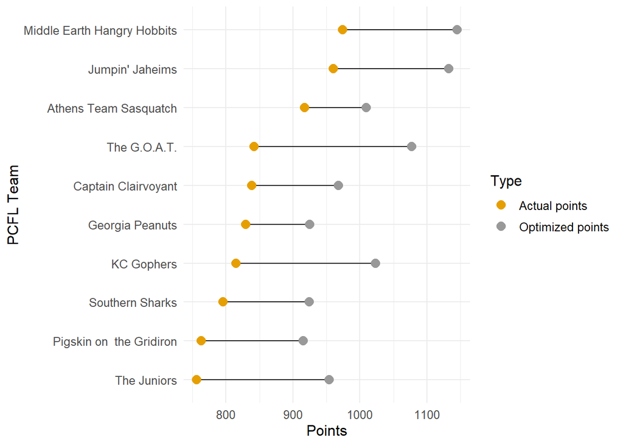

Scott and Evan looking good here, though Robbie and me have been pretty efficient with what we have.

### Best additions

There were 12 players added last week. Which was the **best new addition**?

| PCFL Team | Player | NFL Team | Position | Points |
| --- | --- | --- | --- | --- |
| Southern Sharks | DJ Moore | CAR | WR | 25.50 |
| Southern Sharks | Andy Dalton | NOS | QB | 17.16 |
| Captain Clairvoyant | Jerry Jeudy | DEN | WR | 15.30 |
| Jumpin’ Jaheims | Younghoe Koo | ATL | K | 14.00 |
| Southern Sharks | Tyler Boyd | CIN | WR | 11.30 |
| Athens Team Sasquatch | Jason Myers | SEA | K | 11.00 |
| Southern Sharks | Greg Dulcich | DEN | TE | 10.70 |
| Pigskin on the Gridiron | Daniel Jones | NYG | QB | 9.04 |
| Georgia Peanuts | Gus Edwards | BAL | RB | 6.50 |
| Southern Sharks | Colts D/ST | IND | DST | 4.00 |
| Georgia Peanuts | Wan’Dale Robinson | NYG | WR | 2.50 |
| Captain Clairvoyant | Allen Lazard | GBP | WR | 0.00 |

Redemption week for DJ Moore.

### Best team performances

Here’s a list of the **top five scoring performances** so far this season.

| PCFL Team | Week | Score | Result |
| --- | --- | --- | --- |
| Athens Team Sasquatch | 8 | 153.85 | W |
| Southern Sharks | 8 | 150.26 | L |
| Middle Earth Hangry Hobbits | 1 | 148.06 | W |
| Georgia Peanuts | 2 | 147.22 | W |
| Southern Sharks | 4 | 143.96 | W |

We’ve got *TWO* new names at the top with Robbie and Sarah. Bummer that Sarah’s came against Robbie, as she would have one literally ANY other matchup so far this season.

## Looking ahead

### League standings

| PCFL Team | Division | Points scored | Avg points | Avg last 3 | W | L | Team points |
| --- | --- | --- | --- | --- | --- | --- | --- |
| Jumpin’ Jaheims | Grits | 960.60 | 120.08 | 113.91 | 7 | 1 | 13 |
| Athens Team Sasquatch | Grits | 917.63 | 114.70 | 121.60 | 6 | 2 | 12 |
| Middle Earth Hangry Hobbits | Hot Dish | 974.44 | 121.80 | 112.41 | 5 | 3 | 11 |
| The G.O.A.T. | Grits | 841.88 | 105.24 | 88.90 | 3 | 5 | 8 |
| KC Gophers | Hot Dish | 814.86 | 101.86 | 93.39 | 4 | 4 | 8 |
| Georgia Peanuts | Hot Dish | 829.42 | 103.68 | 106.92 | 4 | 4 | 7 |
| The Juniors | Hot Dish | 755.87 | 94.48 | 91.20 | 4 | 4 | 6 |
| Captain Clairvoyant | Grits | 838.16 | 104.77 | 100.27 | 3 | 5 | 6 |
| Pigskin on the Gridiron | Grits | 762.66 | 95.33 | 106.22 | 3 | 5 | 6 |
| Southern Sharks | Hot Dish | 795.40 | 99.42 | 103.43 | 1 | 7 | 3 |

Evan remains on top even with the loss last week. However, Scott still has the points lead. I’ve added the points per game average for the last three weeks to see how teams are trending up (Robbie, me, Richard, Sarah) or down (Erin/Trav, Crissy, Jacob).

### If the season ended today…

Current playoff teams (ESPN): Evan and Scott as division winners, Robbie and me as wildcards

Current playoff teams (Team points): Evan, Robbie, Scott, and Jacob

### Next week’s matchups

| Team 1 | Team 2 |
| --- | --- |
| Athens Team Sasquatch (Avg. last 3: 121.6) | Captain Clairvoyant (Avg. last 3: 100.27) |
| Georgia Peanuts (Avg. last 3: 106.92) | The Juniors (Avg. last 3: 91.2) |
| Jumpin’ Jaheims (Avg. last 3: 113.91) | Pigskin on the Gridiron (Avg. last 3: 106.22) |
| KC Gophers (Avg. last 3: 93.39) | Middle Earth Hangry Hobbits (Avg. last 3: 112.41) |
| Southern Sharks (Avg. last 3: 103.43) | The G.O.A.T. (Avg. last 3: 88.9) |

We’ll see if Evan can get on track next week against the suddenly surging Pigskin on the Gridiron. Scott tries to knock Crissy out a playoff spot. Robbie and Brian face off in a matchup of playoff perennials. Sarah tries to make up some ground against the fading GOAT, and I face off against Erin and Trav.

Good luck, y’all! (And check your byes!)